# TRABAJO MODELOS

Amparo Gálvez Vilar, Lidia Moreno Marín y Lucía Carro Arcaya

# DESCRIPCIÓN DEL BANCO DE DATOS

El Cuestionario Estudiantil Global de Bienestar (CEGB) es un estudio escolar que emplea un formulario autoadministrado para recolectar información sobre el estado de salud de los jóvenes y los elementos de prevención vinculados a las causas principales de enfermedades y muertes.

El sondeo fue efectuado en Argentina en el año 2018. Un total de 56.981 alumnos participaron en él. En total tenemos 18 variables, en un principio utilizaremos todas para sacar conclusiones.

# OBJETIVOS DEL ESTUDIO

Desarrollar un modelo que nos permita predecir el bullying a partir de las variables del dataset. Antes de esto, realizaremos un análisis de las variables que más influyen en el bullying.

Vamos a ver los porcentajes de bullying en función de la edad, teniendo en cuenta también en el modelo otras variables como si se sentían solos, el sexo y la situación familiar.

Nuestra variable respuesta será el bullying, variable de tipo factor que nos indica si hay o no bullying.

Realizamos el estudio a partir de estas variables ya que sacar conclusiones de estos aspectos puede darnos información relevante sobre la sociedad actual.

# PREPARACIÓN DE LOS DATOS

Importamos y cargamos los datos archivo csv:

```r
bullying <- read_delim("Bullying_2018.csv", delim = ";", escape_double = FALSE, trim_ws = TRUE)
bullying<-drop_na(bullying)
```

Quitamos del dataframe las vaiables que no son útiles:

```r
bullying <- bullying %>% select(-record, -Bullied_not_on_school_property_in_past_12_months,
                                -Most_of_the_time_or_always_felt_lonely,
                                -Miss_school_no_permission)
```

Convertimos las variables de tipo character a tipo factor:

```r
names(bullying)[1] <- 'Bullying'

bullying$Bullying <- as.factor(bullying$Bullying)
levels(bullying$Bullying) <- c("0", "1")

bullying$Cyber_bullied_in_past_12_months <- as.factor(bullying$Cyber_bullied_in_past_12_months)

bullying$Sex <- as.factor(bullying$Sex)

bullying$Physically_attacked <- as.factor(bullying$Physically_attacked)

bullying$Physical_fighting <- as.factor(bullying$Physical_fighting)

bullying$Felt_lonely <- as.factor(bullying$Felt_lonely)

bullying$Close_friends <-  as.factor(bullying$Close_friends)

bullying$Other_students_kind_and_helpful <- as.factor(bullying$Other_students_kind_and_helpful)

bullying$Parents_understand_problems <- as.factor(bullying$Parents_understand_problems)

bullying$Missed_classes_or_school_without_permission <- as.factor(
  bullying$Missed_classes_or_school_without_permission)
```

Convertimos la columna edad a númerica:

```r
bullying <- bullying %>% mutate(Custom_Age = as.numeric(gsub("[^0-9]", "", Custom_Age)))
```

Contruimos la variable peso:

```r
bullying$Were_underweight <- as.factor(bullying$Were_underweight)
bullying$Were_overweight <- as.factor(bullying$Were_overweight)
bullying$Were_obese <- as.factor(bullying$Were_obese)

peso <- rep("Normal", 32938)

under <- bullying$Were_underweight == 'Yes'
under <- which(under)

for (i in under){
  peso[i] = 'BajoPeso'
}

over <- bullying$Were_overweight == 'Yes'
over <- which(over)

for (i in over){
  peso[i] = 'SobrePeso'
}

obese <- bullying$Were_obese == 'Yes'
obese <- which(obese)

for (i in obese){
  peso[i] = 'Obeso'
}

bullying$Peso <- as.factor(peso)

bullying <- bullying %>% select(-Were_obese, -Were_overweight, -Were_underweight)
```

Antes que nada vamos a visualizar manera gráfica el número de niños que sufren bullying de nuestro banco de datos, esto lo tendremos en cuenta para analizar los resultados obtenidos.

```r
prop_table_bullying <- prop.table(table(bullying$Bullying)) * 100
print(prop_table_bullying)
```

```
##
##        0        1
## 79.14263 20.85737
```

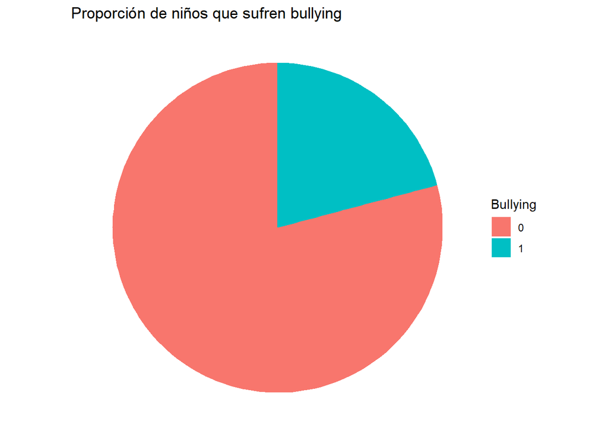

```r
# Podemos hablar del porcentaje

ggplot(bullying, aes(x = "", fill = Bullying)) +
  geom_bar(width = 1) +
  coord_polar(theta = "y") +
  labs(title = "Proporción de niños que sufren bullying",
       fill = "Bullying",
       x = NULL,
       y = NULL) +
  theme_void()
```

# SELECCIÓN DEL MODELO

Trabajeremos con los modelos y sacaremos las conlcuisones a partir de el grupo de entrenamienot y el grupo de prueba.

[output not shown]

Sabiendo que nuestra variable respuesta es categórica vamos a utilizar el modelo de regresión logistica múltiple, dado que esta modela la probabilidad de que nuestra variable pertenezca a una categoría en particular.

Vamos a relalizar dos modelos utilizando diferentes grupos de variables para ver cual de los dos funcionará mejor.

El primer modelo lo realizaremos en base a las variables que nos parecen más relevantes, y el segundo a partir de la función step.

## MODELO 1:

```r
modelo1 <- glm(Bullying ~ Custom_Age + Peso + Close_friends,
               data = bullying, family = binomial)
step(modelo1)
```

```
## Start:  AIC=33486.96
## Bullying ~ Custom_Age + Peso + Close_friends
##
##                 Df Deviance   AIC
## <none>                33471 33487
## - Peso           3    33482 33492
## - Custom_Age     1    33580 33594
## - Close_friends  3    33621 33631
```

```
##
## Call:  glm(formula = Bullying ~ Custom_Age + Peso + Close_friends, family = binomial,
##     data = bullying)
##
## Coefficients:
##            (Intercept)              Custom_Age              PesoNormal
##                0.75642                -0.10594                -0.14686
##              PesoObeso           PesoSobrePeso          Close_friends1
##               -0.02823                -0.06364                -0.11022
##         Close_friends2  Close_friends3 or more
##               -0.23245                -0.49427
##
## Degrees of Freedom: 32937 Total (i.e. Null);  32930 Residual
## Null Deviance:       33730
## Residual Deviance: 33470     AIC: 33490
```

Sabemos que cuanto menor sea el AIC mejor es nuestro modelo. Por tanto, observando la función step, el mejor modelo posible es no quitar ninguna variable, ya que obtenemos el menor AIC.

```r
summary(modelo1)
```

```
##
## Call:
## glm(formula = Bullying ~ Custom_Age + Peso + Close_friends, family = binomial,
##     data = bullying)
##
## Deviance Residuals:
##     Min       1Q   Median       3Q      Max
## -0.9275  -0.7061  -0.6422  -0.5831   1.9727
##
## Coefficients:
##                        Estimate Std. Error z value Pr(>|z|)
## (Intercept)             0.75642    0.18520   4.084 4.42e-05 ***
## Custom_Age             -0.10594    0.01016 -10.423  < 2e-16 ***
## PesoNormal             -0.14686    0.09453  -1.554 0.120294
## PesoObeso              -0.02823    0.10516  -0.268 0.788364
## PesoSobrePeso          -0.06364    0.09722  -0.655 0.512742
## Close_friends1         -0.11022    0.06957  -1.584 0.113138
## Close_friends2         -0.23245    0.06234  -3.729 0.000193 ***
## Close_friends3 or more -0.49427    0.05623  -8.790  < 2e-16 ***
## ---
## Signif. codes:  0 '***' 0.001 '**' 0.01 '*' 0.05 '.' 0.1 ' ' 1
##
## (Dispersion parameter for binomial family taken to be 1)
##
##     Null deviance: 33733  on 32937  degrees of freedom
## Residual deviance: 33471  on 32930  degrees of freedom
## AIC: 33487
##
## Number of Fisher Scoring iterations: 4
```

Con la función summary vemos la variables respuesta, en nuestro caso ‘Bullying’ que puede tener dos valores (0 o 1), con las covariables ‘Custom_Age’, ‘Peso’ y ‘Close_friends’.

En la columna “Estimate” encontramos los coeficientes estimados para cada variable predictora. Por ejemplo, el coeficiente estimado para “Custom_Age” es -0.10594. Esto indica que, manteniendo constantes las otras variables, se espera que un aumento de una unidad en “Custom_Age” esté asociado con una disminución en las probabilidades de experimentar bullying.

Vemos los parámetros significativos cuando la columna “Pr(>|z|)” presentan un valor pequeño de p (generalmente < 0.05). Por ejemplo los coeficinetes de edad, tener 2 mejores amigos y tener 3 o más mejores amigos tienen valores p muy pequeños, lo que significa que son significativos.

### PREDICCIONES

A continuación, realizamos las predicciones del modelo, estas nos dirán si el modelo está bien ajustado y que probabilidad de acierto tiene.

```r
modelo_entren <- glm(Bullying ~ Custom_Age + Peso + Close_friends,
               data = bullying, family = binomial, subset = train)

n2.prob <- predict(modelo_entren, held.out, type="response")
```

```r
modelo_entren.pred <- rep("0_NoBullying", 9500)

modelo_entren.pred[n2.prob > 0.5] <- "1_YesBullying"

(tt<-table(held.out.B, modelo_entren.pred))
```

```
##           modelo_entren.pred
## held.out.B 0_NoBullying
##          0         7518
##          1         1982
```

Este modelo no nos ayuda a llegar a la conclusión que queremos obtener, ya que vemos que no predice que ningún niño sufra bullying.

Esto se debe a que las probabilidades predichas en función a nuestro modelo son todas más pequeñas que 0.5, que es el rango que hemos definido. Por lo tanto, vemos que las variables elegidas no influyen lo suficiente para que el modelo sea bueno.

## MODELO 2:

```r
modelo2 <- glm(Bullying ~ Cyber_bullied_in_past_12_months +
                 Custom_Age + Sex + Physically_attacked +
                 Physical_fighting + Felt_lonely + Close_friends +
                 Other_students_kind_and_helpful + Parents_understand_problems +
                 Missed_classes_or_school_without_permission + Peso ,
               data=bullying, family = binomial)

step(modelo2)
```

```
## Start:  AIC=29828.79
## Bullying ~ Cyber_bullied_in_past_12_months + Custom_Age + Sex +
##     Physically_attacked + Physical_fighting + Felt_lonely + Close_friends +
##     Other_students_kind_and_helpful + Parents_understand_problems +
##     Missed_classes_or_school_without_permission + Peso
##
##                                               Df Deviance   AIC
## - Physical_fighting                            7    29766 29826
## - Missed_classes_or_school_without_permission  1    29755 29827
## - Sex                                          1    29756 29828
## <none>                                              29755 29829
## - Close_friends                                3    29761 29829
## - Parents_understand_problems                  4    29770 29836
## - Peso                                         3    29771 29839
## - Custom_Age                                   1    29930 30002
## - Other_students_kind_and_helpful              4    30000 30066
## - Physically_attacked                          7    30034 30094
## - Felt_lonely                                  4    30212 30278
## - Cyber_bullied_in_past_12_months              1    31282 31354
##
## Step:  AIC=29825.85
## Bullying ~ Cyber_bullied_in_past_12_months + Custom_Age + Sex +
##     Physically_attacked + Felt_lonely + Close_friends + Other_students_kind_and_helpful +
##     Parents_understand_problems + Missed_classes_or_school_without_permission +
##     Peso
##
##                                               Df Deviance   AIC
## - Missed_classes_or_school_without_permission  1    29766 29824
## - Sex                                          1    29766 29824
## <none>                                              29766 29826
## - Close_friends                                3    29772 29826
## - Parents_understand_problems                  4    29782 29834
## - Peso                                         3    29782 29836
## - Custom_Age                                   1    29941 29999
## - Other_students_kind_and_helpful              4    30011 30063
## - Physically_attacked                          7    30046 30092
## - Felt_lonely                                  4    30221 30273
## - Cyber_bullied_in_past_12_months              1    31291 31349
##
## Step:  AIC=29823.93
```

[output cut: 16 more lines]

```
## Step:  AIC=29822.23
## Bullying ~ Cyber_bullied_in_past_12_months + Custom_Age + Physically_attacked +
##     Felt_lonely + Close_friends + Other_students_kind_and_helpful +
##     Parents_understand_problems + Peso
##
##                                   Df Deviance   AIC
## <none>                                  29766 29822
## - Close_friends                    3    29773 29823
## - Parents_understand_problems      4    29783 29831
## - Peso                             3    29783 29833
## - Custom_Age                       1    29944 29998
## - Other_students_kind_and_helpful  4    30012 30060
## - Physically_attacked              7    30054 30096
## - Felt_lonely                      4    30249 30297
## - Cyber_bullied_in_past_12_months  1    31308 31362
```

```
##
## Call:  glm(formula = Bullying ~ Cyber_bullied_in_past_12_months + Custom_Age +
##     Physically_attacked + Felt_lonely + Close_friends + Other_students_kind_and_helpful +
##     Parents_understand_problems + Peso, family = binomial, data = bullying)
##
## Coefficients:
##                                     (Intercept)
##                                         0.94572
##              Cyber_bullied_in_past_12_monthsYes
##                                         1.23927
##                                      Custom_Age
##                                        -0.14673
##                       Physically_attacked1 time
##                                         0.43394
##               Physically_attacked10 or 11 times
##                                         0.80405
##             Physically_attacked12 or more times
##                                         0.86069
##                 Physically_attacked2 or 3 times
##                                         0.71299
##                 Physically_attacked4 or 5 times
##                                         0.82331
##                 Physically_attacked6 or 7 times
##                                         0.60828
##                 Physically_attacked8 or 9 times
##                                         0.52117
##                     Felt_lonelyMost of the time
##                                        -0.05167
##                                Felt_lonelyNever
##                                        -0.99778
##                               Felt_lonelyRarely
##                                        -0.76082
##                            Felt_lonelySometimes
##                                        -0.41643
##                                  Close_friends1
##                                        -0.07780
##                                  Close_friends2
##                                        -0.14210
##                          Close_friends3 or more
##                                        -0.14261
```

[output cut: 11 more lines]

```
##                                        -0.15107
##               Parents_understand_problemsRarely
##                                        -0.14014
##            Parents_understand_problemsSometimes
##                                        -0.04171
##                                      PesoNormal
##                                        -0.17881
##                                       PesoObeso
##                                        -0.02228
##                                   PesoSobrePeso
##                                        -0.06990
##
## Degrees of Freedom: 32937 Total (i.e. Null);  32910 Residual
## Null Deviance:       33730
## Residual Deviance: 29770     AIC: 29820
```

```r
modelo3 <- glm(Bullying ~ Other_students_kind_and_helpful + Physically_attacked +
                 Felt_lonely + Cyber_bullied_in_past_12_months,
               data = bullying, family = binomial)

step(modelo3)
```

```
## Start:  AIC=30029.72
## Bullying ~ Other_students_kind_and_helpful + Physically_attacked +
##     Felt_lonely + Cyber_bullied_in_past_12_months
##
##                                   Df Deviance   AIC
## <none>                                  29996 30030
## - Other_students_kind_and_helpful  4    30248 30274
## - Physically_attacked              7    30297 30317
## - Felt_lonely                      4    30431 30457
## - Cyber_bullied_in_past_12_months  1    31509 31541
```

```
##
## Call:  glm(formula = Bullying ~ Other_students_kind_and_helpful + Physically_attacked +
##     Felt_lonely + Cyber_bullied_in_past_12_months, family = binomial,
##     data = bullying)
##
## Coefficients:
##                                     (Intercept)
##                                        -1.61304
## Other_students_kind_and_helpfulMost of the time
##                                         0.14170
##            Other_students_kind_and_helpfulNever
##                                         0.66723
##           Other_students_kind_and_helpfulRarely
##                                         0.61147
##        Other_students_kind_and_helpfulSometimes
##                                         0.42247
##                       Physically_attacked1 time
##                                         0.44558
##               Physically_attacked10 or 11 times
##                                         0.83732
##             Physically_attacked12 or more times
##                                         0.89827
##                 Physically_attacked2 or 3 times
##                                         0.70923
##                 Physically_attacked4 or 5 times
##                                         0.82808
##                 Physically_attacked6 or 7 times
##                                         0.61883
##                 Physically_attacked8 or 9 times
##                                         0.57038
##                     Felt_lonelyMost of the time
##                                        -0.05689
##                                Felt_lonelyNever
##                                        -0.90398
##                               Felt_lonelyRarely
##                                        -0.71176
##                            Felt_lonelySometimes
##                                        -0.40185
##              Cyber_bullied_in_past_12_monthsYes
##                                         1.21936
##
## Degrees of Freedom: 32937 Total (i.e. Null);  32921 Residual
## Null Deviance:       33730
## Residual Deviance: 30000     AIC: 30030
```

```r
summary(modelo3)
```

```
##
## Call:
## glm(formula = Bullying ~ Other_students_kind_and_helpful + Physically_attacked +
##     Felt_lonely + Cyber_bullied_in_past_12_months, family = binomial,
##     data = bullying)
##
## Deviance Residuals:
##     Min       1Q   Median       3Q      Max
## -1.6981  -0.6430  -0.5003  -0.3940   2.2780
##
## Coefficients:
##                                                 Estimate Std. Error z value
## (Intercept)                                     -1.61304    0.06862 -23.508
## Other_students_kind_and_helpfulMost of the time  0.14170    0.04856   2.918
## Other_students_kind_and_helpfulNever             0.66723    0.06326  10.548
## Other_students_kind_and_helpfulRarely            0.61147    0.05018  12.185
## Other_students_kind_and_helpfulSometimes         0.42247    0.04856   8.701
## Physically_attacked1 time                        0.44558    0.04554   9.784
## Physically_attacked10 or 11 times                0.83732    0.28292   2.960
## Physically_attacked12 or more times              0.89827    0.10979   8.181
## Physically_attacked2 or 3 times                  0.70923    0.06257  11.335
## Physically_attacked4 or 5 times                  0.82808    0.10907   7.593
## Physically_attacked6 or 7 times                  0.61883    0.17243   3.589
## Physically_attacked8 or 9 times                  0.57038    0.22174   2.572
## Felt_lonelyMost of the time                     -0.05689    0.06494  -0.876
## Felt_lonelyNever                                -0.90398    0.06325 -14.291
## Felt_lonelyRarely                               -0.71176    0.06237 -11.411
## Felt_lonelySometimes                            -0.40185    0.06031  -6.663
## Cyber_bullied_in_past_12_monthsYes               1.21936    0.03092  39.434
##                                                 Pr(>|z|)
## (Intercept)                                      < 2e-16 ***
## Other_students_kind_and_helpfulMost of the time 0.003524 **
## Other_students_kind_and_helpfulNever             < 2e-16 ***
## Other_students_kind_and_helpfulRarely            < 2e-16 ***
## Other_students_kind_and_helpfulSometimes         < 2e-16 ***
## Physically_attacked1 time                        < 2e-16 ***
## Physically_attacked10 or 11 times               0.003081 **
## Physically_attacked12 or more times             2.81e-16 ***
## Physically_attacked2 or 3 times                  < 2e-16 ***
## Physically_attacked4 or 5 times                 3.14e-14 ***
## Physically_attacked6 or 7 times                 0.000332 ***
## Physically_attacked8 or 9 times                 0.010103 *
## Felt_lonelyMost of the time                     0.380981
## Felt_lonelyNever                                 < 2e-16 ***
## Felt_lonelyRarely                                < 2e-16 ***
## Felt_lonelySometimes                            2.69e-11 ***
## Cyber_bullied_in_past_12_monthsYes               < 2e-16 ***
## ---
## Signif. codes:  0 '***' 0.001 '**' 0.01 '*' 0.05 '.' 0.1 ' ' 1
##
## (Dispersion parameter for binomial family taken to be 1)
##
##     Null deviance: 33733  on 32937  degrees of freedom
## Residual deviance: 29996  on 32921  degrees of freedom
## AIC: 30030
##
## Number of Fisher Scoring iterations: 4
```

La variabale respuesta de este modelo vulve a ser Bullying, las covariables son “Other_students_kind_and_helpful”, “Physically_attacked”, “Felt_lonely” y “Cyber_bullied_in_past_12_months”.

En la columna “Estimate” encontramos los coeficientes estimados para cada variable predictora. Por ejemplo: “Other_students_kind_and_helpfulMost of the time” es 0.14170. Esto indica que, manteniendo constantes las otras variables, se espera que los individuos que informaron que otros estudiantes son amables y serviciales “la mayoría del tiempo” tengan un aumento en el logaritmo de las probabilidades de experimentar bullying.

### PREDICCIONES

```r
modelo_entren <- glm(Bullying ~ Other_students_kind_and_helpful +
                 Physically_attacked +
                 Felt_lonely +
                 Cyber_bullied_in_past_12_months,
               data = bullying, family = binomial, subset = train)

n2.prob <- predict(modelo_entren, held.out, type="response")
```

```r
modelo_entren.pred <- rep("0_NoBullying", 9500)

modelo_entren.pred[n2.prob > 0.5] <- "1_YesBullying"

(tt<-table(held.out.B, modelo_entren.pred))
```

```
##           modelo_entren.pred
## held.out.B 0_NoBullying 1_YesBullying
##          0         7244           274
##          1         1648           334
```

```r
# ESPECIFIDAD:
spe<-tt[1,1]/sum(tt[1,])
# SENSIBILIDAD:
sen<-tt[2,2]/sum(tt[2,])

cat('Sensibilidad:',sen,'\nEspecificidad:',spe)
```

```
## Sensibilidad: 0.1685166
## Especificidad: 0.9635541
```

```r
tot<-(tt[1,1] + tt[2,2]) / sum(tt)
cat('\nBien clasificados (Bayes):',round(100*tot,2),'%')
```

```
##
## Bien clasificados (Bayes): 79.77 %
```

#### CURVA ROC

```r
curv_roc <- roc(held.out.B, n2.prob)
```

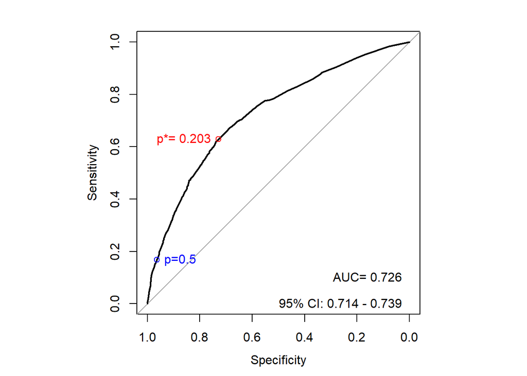

```r
yi<-coords(curv_roc, "best")
par(pty="s")
plot(curv_roc,xlim=c(1,0))
points(spe,sen,col='blue')
text(spe,sen,'p=0.5',col='blue',pos='4')
points(yi[2],yi[3],col='red')
text(yi[2],yi[3],paste('p*=',round(yi[1],3)),col='red',pos='2')
text(0,0.1,paste('AUC=',round(curv_roc$auc,3)),pos=2)
text(0,0,paste('95% CI:',round(ci(curv_roc)[1],3),'-',round(ci(curv_roc)[3],3)),pos=2)
```

#### ERROR DE PREDICCIÓN

```r
mesura.error <- function(x,y) mean(abs(x-y)>0.5)*100

ecm <- cv.glm(bullying, modelo3, cost = mesura.error, K=10)

ecm$delta
```

```
## [1] 20.24409 20.25442
```

El porcentaje de predicciones incorrectas ha sido del 20.25%.

## GRÁFICOS

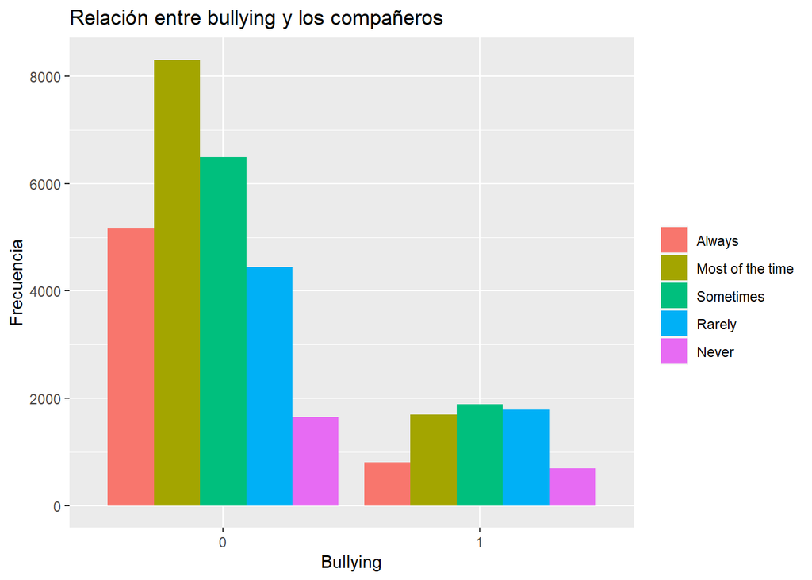

```r
orden = c('Always', 'Most of the time', 'Sometimes', 'Rarely', 'Never')
bullying$Other_students_kind_and_helpful <- factor(bullying$Other_students_kind_and_helpful,
                                                   levels = orden)
ggplot(bullying, aes(x = Bullying, fill = Other_students_kind_and_helpful)) +
  geom_bar(position = "dodge") +
  labs(title = "Relación entre bullying y los compañeros",
       x = "Bullying",
       y = "Frecuencia", fill ='')
```

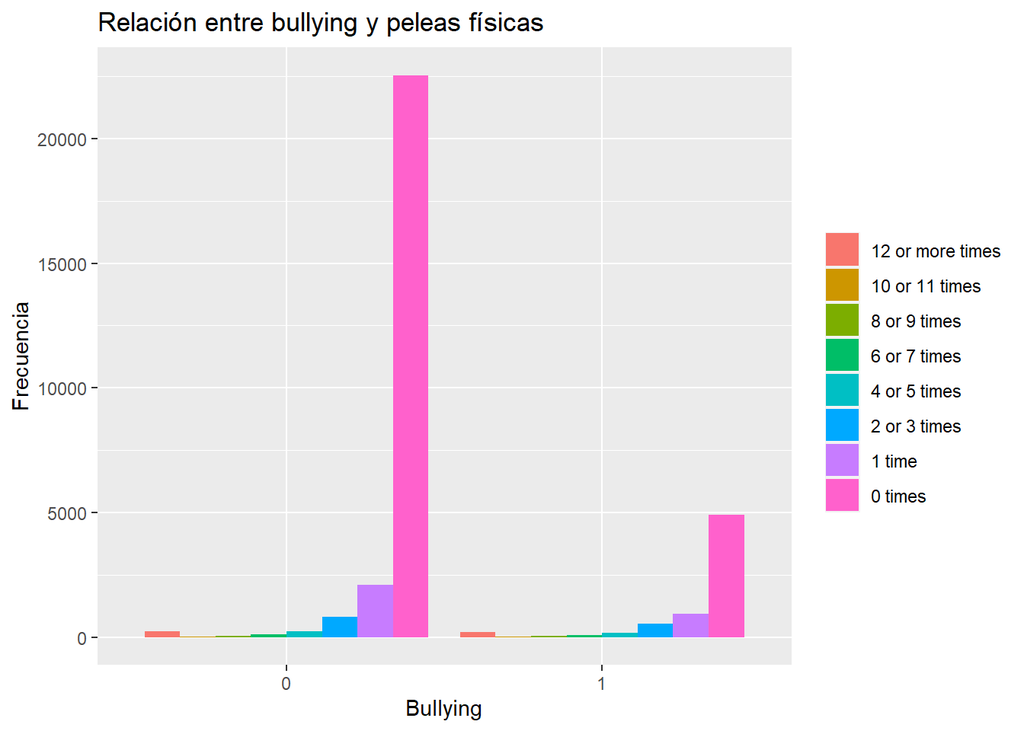

```r
orden = c('12 or more times', '10 or 11 times', '8 or 9 times', '6 or 7 times',
          '4 or 5 times', '2 or 3 times', '1 time', '0 times')
bullying$Physically_attacked <- factor(bullying$Physically_attacked, levels = orden)
ggplot(bullying, aes(x = Bullying, fill = Physically_attacked)) +
  geom_bar(position = "dodge") +
  labs(title = "Relación entre bullying y peleas físicas",
       x = "Bullying",
       y = "Frecuencia", fill ='')
```

```r
filtrado <- bullying %>% filter(Physically_attacked == c('2 or 3 times', '4 or 5 times',
                                                        '6 or 7 times',
                                                        '8 or 9 times', '10 or 11 times',
                                                        '12 or more times'))
```

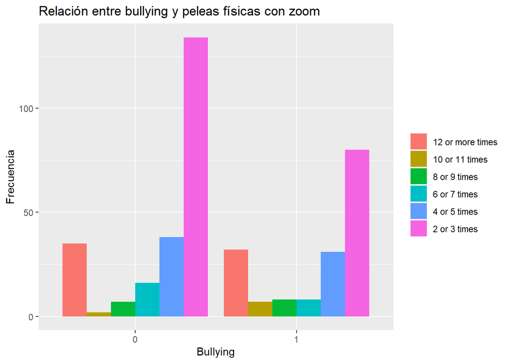

```r
ggplot(filtrado, aes(x = Bullying, fill = Physically_attacked)) +
  geom_bar(position = "dodge") +
  labs(title = "Relación entre bullying y peleas físicas con zoom",
       x = "Bullying",
       y = "Frecuencia", fill ='')
```

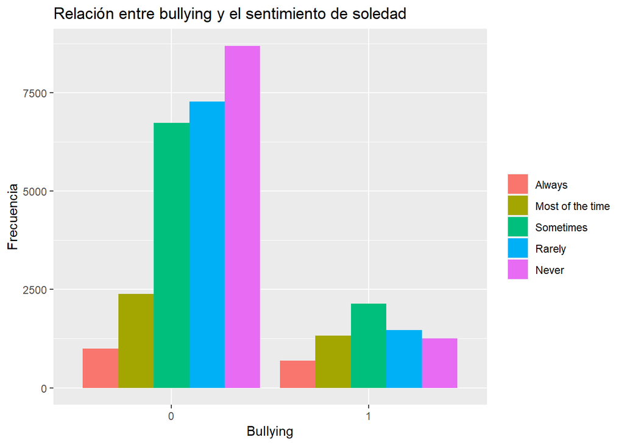

```r
orden = c('Always', 'Most of the time', 'Sometimes', 'Rarely', 'Never')
bullying$Felt_lonely <- factor(bullying$Felt_lonely, levels = orden)

ggplot(bullying, aes(x = Bullying, fill = Felt_lonely)) +
  geom_bar(position = "dodge") +
  labs(title = "Relación entre bullying y el sentimiento de soledad",
       x = "Bullying",
       y = "Frecuencia", fill ='')
```

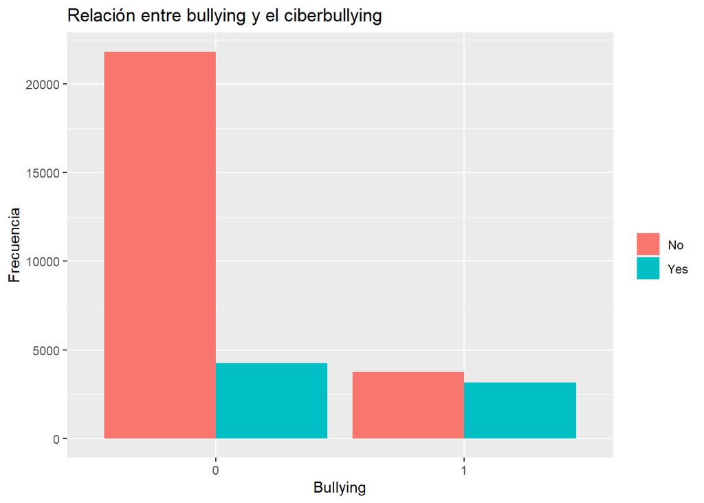

```r
ggplot(bullying, aes(x = Bullying, fill = Cyber_bullied_in_past_12_months)) +
  geom_bar(position = "dodge") +
  labs(title = "Relación entre bullying y el ciberbullying",
       x = "Bullying",
       y = "Frecuencia", fill ='')
```